# Genomic Data Visualization using R

Jubayer Hossain

23 February, 2021

## What is ggplot2?

- ggplot2 is a data visualization package for the statistical programming language R.
- Created by Hadley Wickham in 2005, ggplot2 is an implementation of Leland Wilkinson’s Grammar of Graphics—a general scheme for data visualization which breaks up graphs into semantic components such as scales and layers.

## Types of Visualization

In statistics, we generally have two kinds of visualization:

- Exploratory data visualization: Exploring the data visually to find patterns among the data entities.
- Explanatory data visualization: Showcasing the identified patterns using simple graphs.

## Why Visualization?

“A picture is worth a thousand words”

- Data visualizations make big and small data easier for the human brain to understand, and visualization also makes it easier to detect patterns, trends, and outliers in groups of data.
- Good data visualizations should place meaning into complicated datasets so that their message is clear and concise.

## Grammar of Graphics

- Data - The dataset being plotted
- Aesthetics- The scales onto which we plot our data
- Geometry - The visual elements used for our data
- Facet -Groups by which we divide the data

## Load Packages and Set Theme

```r
library(tidyverse)
library(gridExtra)
theme_set(theme_gray(base_size = 18))
```

## Load Data

```r
data <- read.csv("variants_from_assembly.bed", sep="\t", stringsAsFactors = TRUE, header = FALSE, quote = '')
```

## Exploring Data

```r
# examine first few rows
head(data)
```

```
  V1        V2        V3  V4   V5 V6        V7  V8   V9
1  6 103832058 103832059 SV1  185  + Insertion   0  185
2  6 102958468 102958469 SV2  317  + Insertion -14  303
3  6 102741692 102741693 SV3  130  +  Deletion 130    0
4  6 102283759 102283760 SV4 1271  + Insertion -12 1259
5  6 101194032 101194033 SV5 2864  + Insertion -13 2851
6  6 101056644 101056645 SV6  265  + Insertion   0  265
```

```r
# Colnames
names(data) <-  c("chrom", "start", "stop", "name", "size", "strand", "type", "ref.dist", "query.dist")
```

```r
head(data)
```

```
  chrom     start      stop name size strand      type ref.dist query.dist
1     6 103832058 103832059  SV1  185      + Insertion        0        185
2     6 102958468 102958469  SV2  317      + Insertion      -14        303
3     6 102741692 102741693  SV3  130      +  Deletion      130          0
4     6 102283759 102283760  SV4 1271      + Insertion      -12       1259
5     6 101194032 101194033  SV5 2864      + Insertion      -13       2851
6     6 101056644 101056645  SV6  265      + Insertion        0        265
```

```r
# Data Structures
glimpse(data)
```

```
Rows: 9,556
Columns: 9
$ chrom      <fct> 6, 6, 6, 6, 6, 6, 6, 6, 6, 6, 6, 6, 6, 6, 6, 6, 6, 6, 6, 6…
$ start      <int> 103832058, 102958468, 102741692, 102283759, 101194032, 101…
$ stop       <int> 103832059, 102958469, 102741693, 102283760, 101194033, 101…
$ name       <fct> SV1, SV2, SV3, SV4, SV5, SV6, SV7, SV8, SV9, SV10, SV11, S…
$ size       <int> 185, 317, 130, 1271, 2864, 265, 334, 248, 362, 31, 499, 16…
$ strand     <fct> +, +, +, +, +, +, +, +, +, +, +, +, +, +, +, +, +, +, +, +…
$ type       <fct> Insertion, Insertion, Deletion, Insertion, Insertion, Inse…
$ ref.dist   <int> 0, -14, 130, -12, -13, 0, 0, 8915, 0, 1939, -6, -1141, -2,…
$ query.dist <int> 185, 303, 0, 1259, 2851, 265, 334, 8667, 362, 1908, 493, 4…
```

```r
# Summary
summary(data)
```

```
     chrom          start                stop                name
 1      : 779   Min.   :    55378   Min.   :    55379   SV1    :   1
 2      : 702   1st Qu.: 28750831   1st Qu.: 28750832   SV10   :   1
 7      : 596   Median : 67213567   Median : 67213568   SV100  :   1
 6      : 568   Mean   : 77646932   Mean   : 77646933   SV1000 :   1
 3      : 565   3rd Qu.:116282726   3rd Qu.:116282726   SV10000:   1
 4      : 530   Max.   :249205989   Max.   :249205990   SV10001:   1
 (Other):5816                                           (Other):9550
      size        strand            type         ref.dist
 Min.   :   1.0   +:9556   Contraction:1677   Min.   :-11736
 1st Qu.: 136.0            Deletion   :2257   1st Qu.:    -9
 Median : 307.0            Expansion  :2479   Median :     3
 Mean   : 681.0            Insertion  :3143   Mean   :  1077
 3rd Qu.: 580.2                               3rd Qu.:   348
 Max.   :9951.0                               Max.   :157902

   query.dist
 Min.   :-18243.0
 1st Qu.:     0.0
 Median :   161.0
 Mean   :  1236.4
 3rd Qu.:   758.2
 Max.   :163991.0
```

## Bar Chart

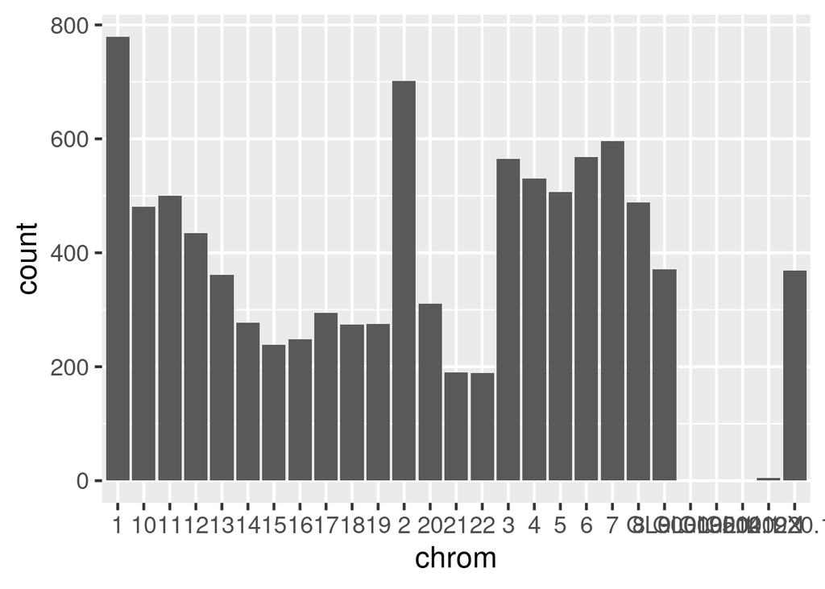

```r
ggplot(data, aes(x=chrom))+
  geom_bar()
```

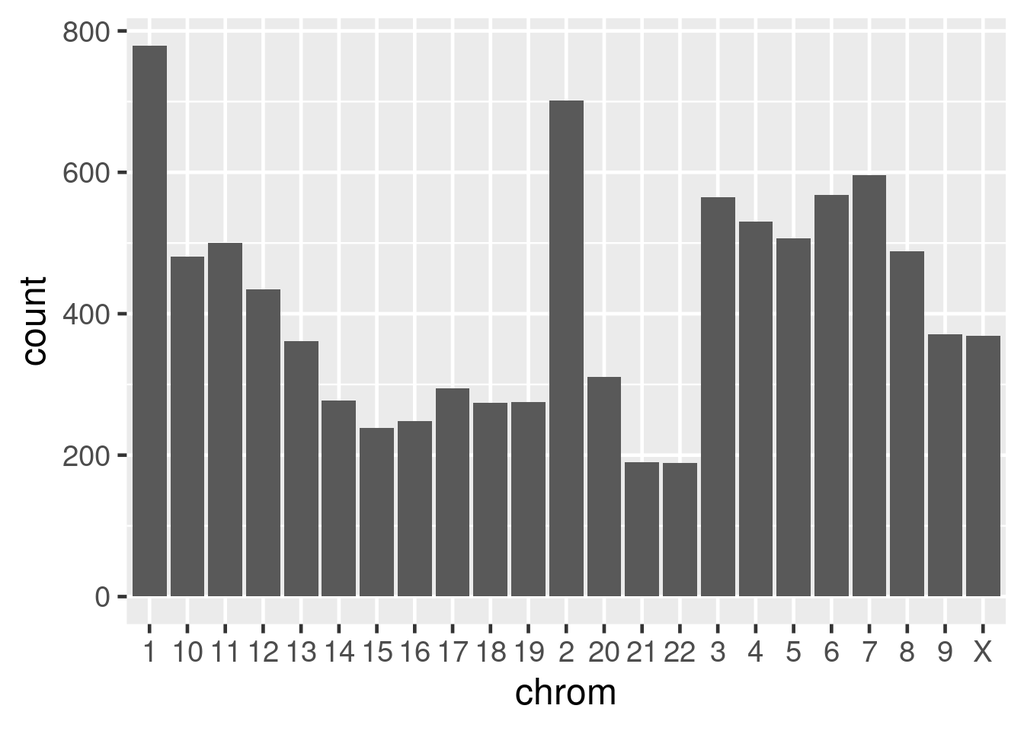

```r
# Filtering Data
data <- filter(data, chrom %in% c(seq(1,22), "X", "Y", "MT"))
ggplot(data, aes(x=chrom))+
  geom_bar()
```

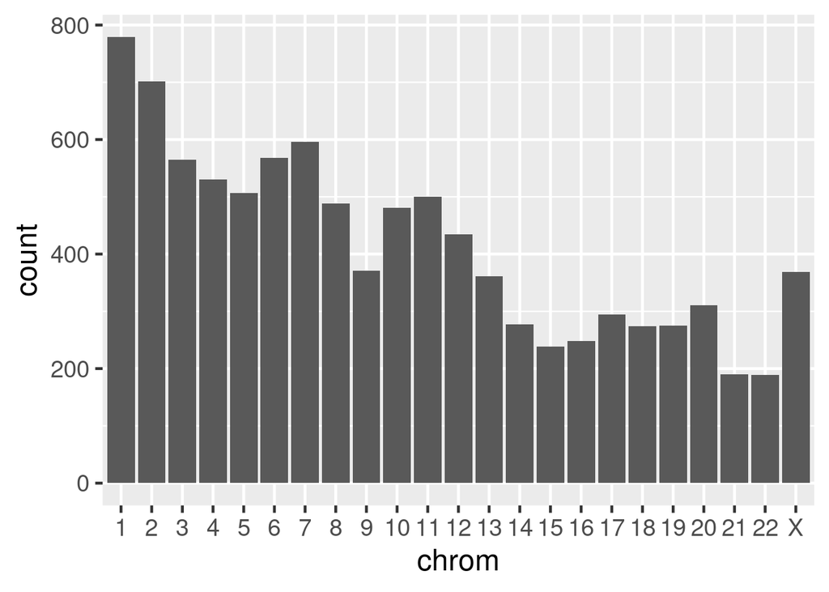

```r
# Ordering Chromosomes
data$chrom <- factor(data$chrom, levels=c(seq(1,22),"X","Y","MT"))
ggplot(data, aes(x=chrom))+
  geom_bar()
```

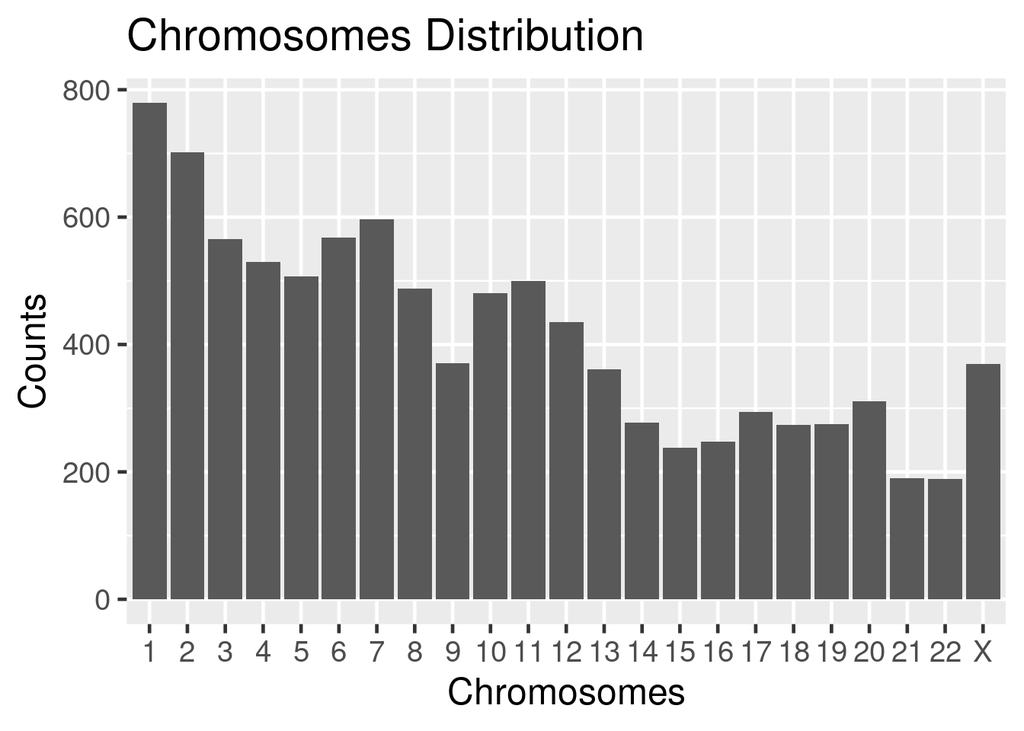

```r
# Xlab, Ylab, Title
ggplot(data, aes(x=chrom))+
  geom_bar()+
  labs(title = "Chromosomes Distribution",
       x="Chromosomes",
       y= "Counts")
```

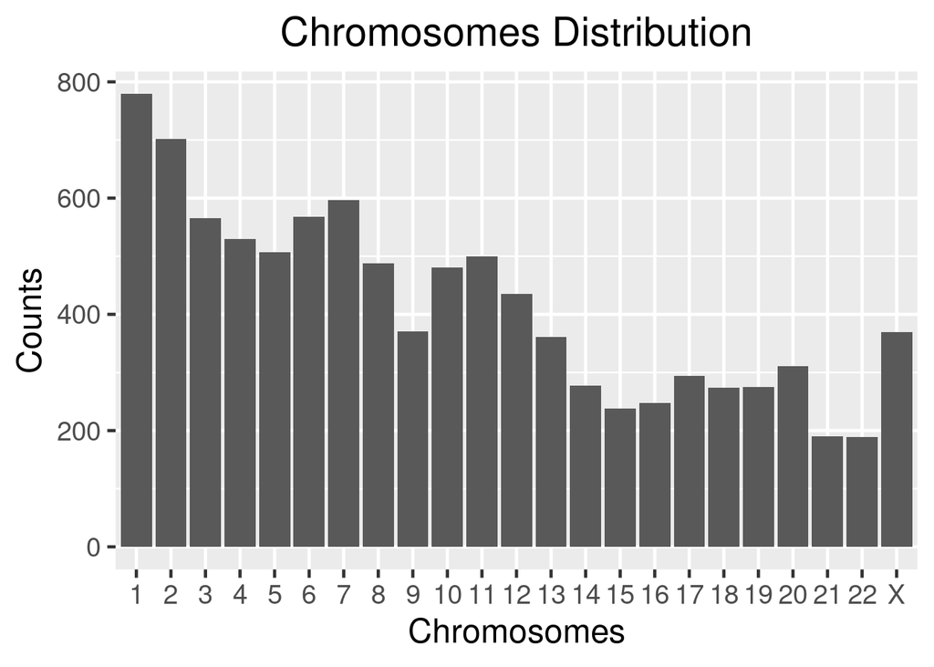

```r
# Centering title
ggplot(data, aes(x=chrom))+
  geom_bar()+
  labs(title = "Chromosomes Distribution",
       x="Chromosomes",
       y= "Counts")+
  theme(plot.title = element_text(hjust = 0.5))
```

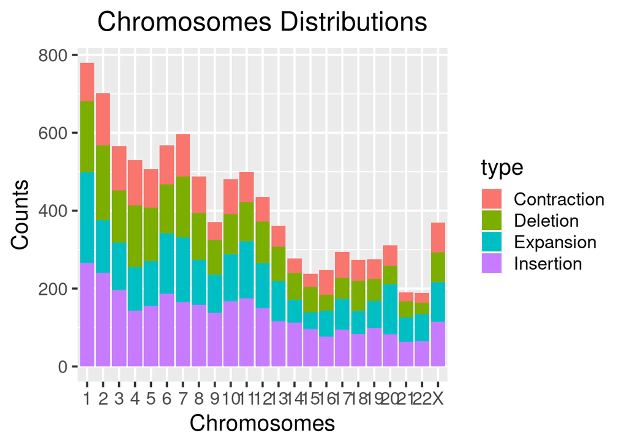

```r
# Color by categorical variable
ggplot(data, aes(x=chrom, fill=type))+
  geom_bar()+
  labs(title = "Chromosomes Distributions",
       x="Chromosomes",
       y= "Counts")+
  theme(plot.title = element_text(hjust = 0.5))
```

```r
# Ordering type
data$type <- factor(data$type, levels = c("Insertion","Deletion",                          "Expansion","Contraction"))
```

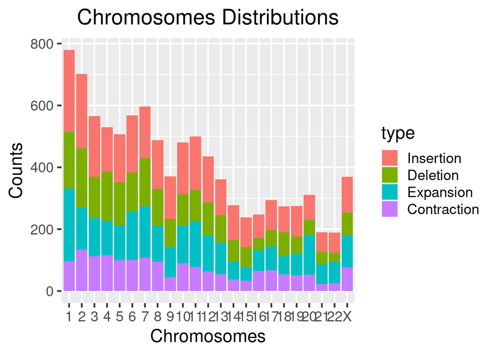

```r
# Color by categorical variable
ggplot(data, aes(x=chrom, fill=type))+
  geom_bar()+
  labs(title = "Chromosomes Distributions",
       x="Chromosomes",
       y= "Counts")+
  theme(plot.title = element_text(hjust = 0.5))
```

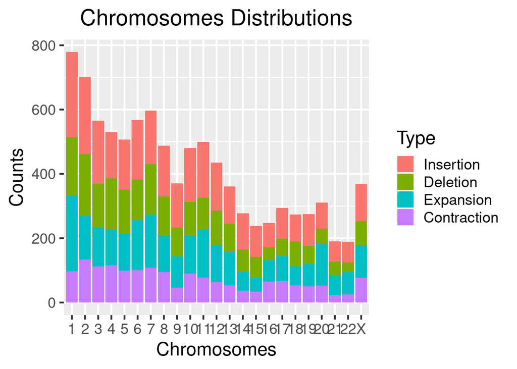

```r
# Color by categorical variable
ggplot(data, aes(x=chrom, fill=type))+
  geom_bar()+
  labs(title = "Chromosomes Distributions",
       x="Chromosomes",
       y= "Counts")+
  theme(plot.title = element_text(hjust = 0.5))+
  guides(fill=guide_legend(title = "Type"))
```

```r
fig <- function(width, heigth){
     options(repr.plot.width = width, repr.plot.height = heigth)
}
```

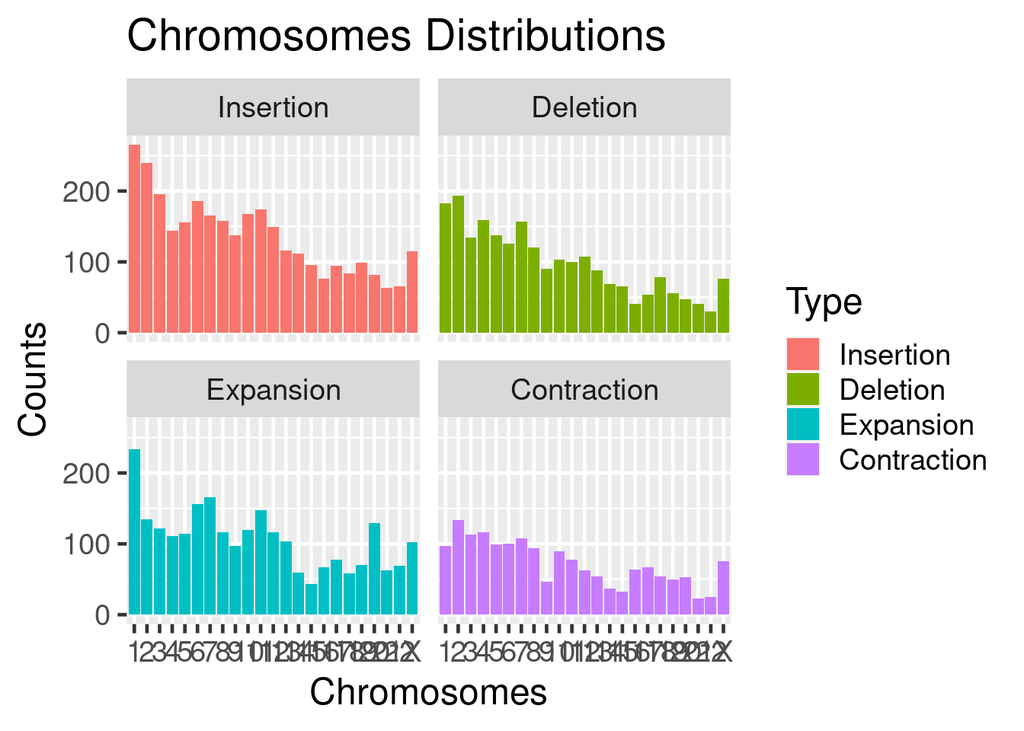

```r
# Facet Wrap
ggplot(data, aes(x=chrom, fill=type))+
  geom_bar()+
  labs(title = "Chromosomes Distributions",
       x="Chromosomes",
       y= "Counts")+
  guides(fill=guide_legend(title = "Type"))+
  facet_wrap(~type)+
  fig(20,6)
```

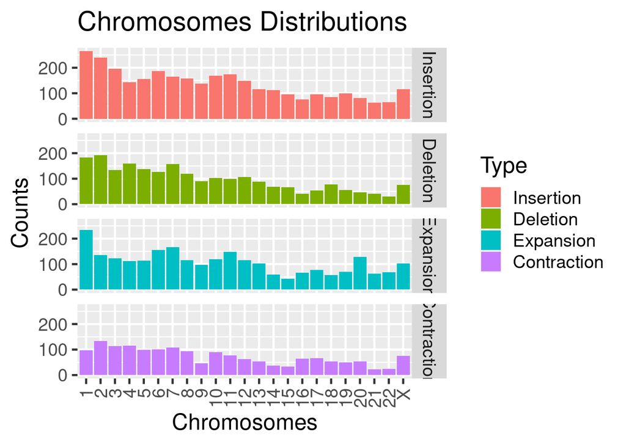

```r
# Facet Grid
ggplot(data, aes(x=chrom, fill=type))+
  geom_bar()+
  labs(title = "Chromosomes Distributions",
       x="Chromosomes",
       y= "Counts")+
  guides(fill=guide_legend(title = "Type"))+
  facet_grid(type ~ .)+
  theme(axis.text.x = element_text(angle = 90, hjust = 1, vjust = 0.5))
```

## Scatter Plot

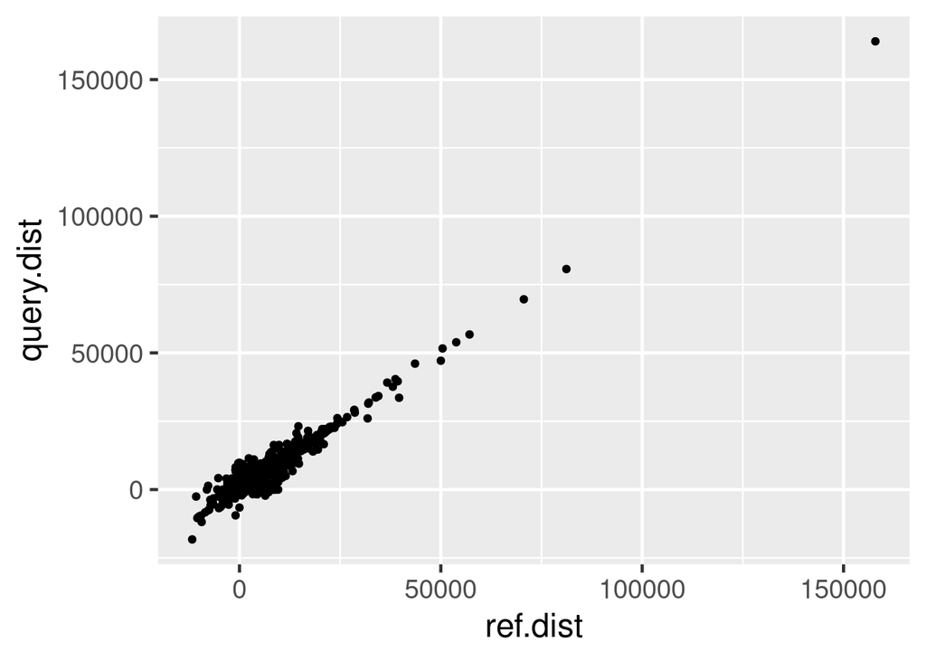

```r
ggplot(data, aes(x=ref.dist, y=query.dist))+
  geom_point()
```

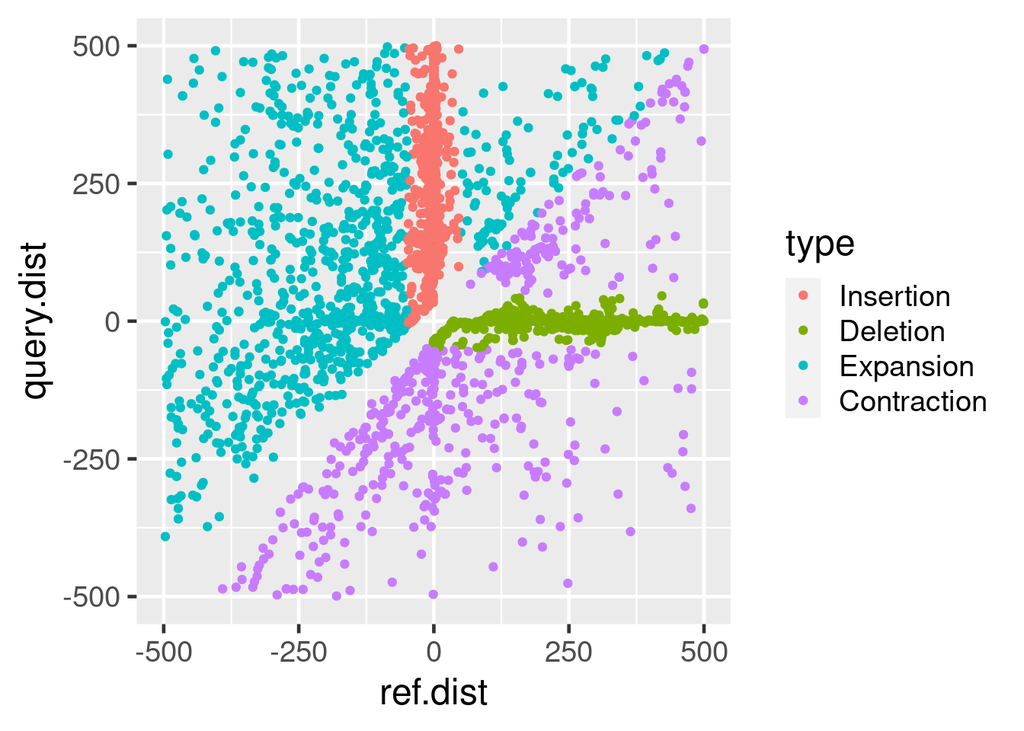

```r
ggplot(data, aes(x=ref.dist, y=query.dist, color=type))+
  geom_point()+
  xlim(-500, 500)+
  ylim(-500, 500)
```

## Boxplot

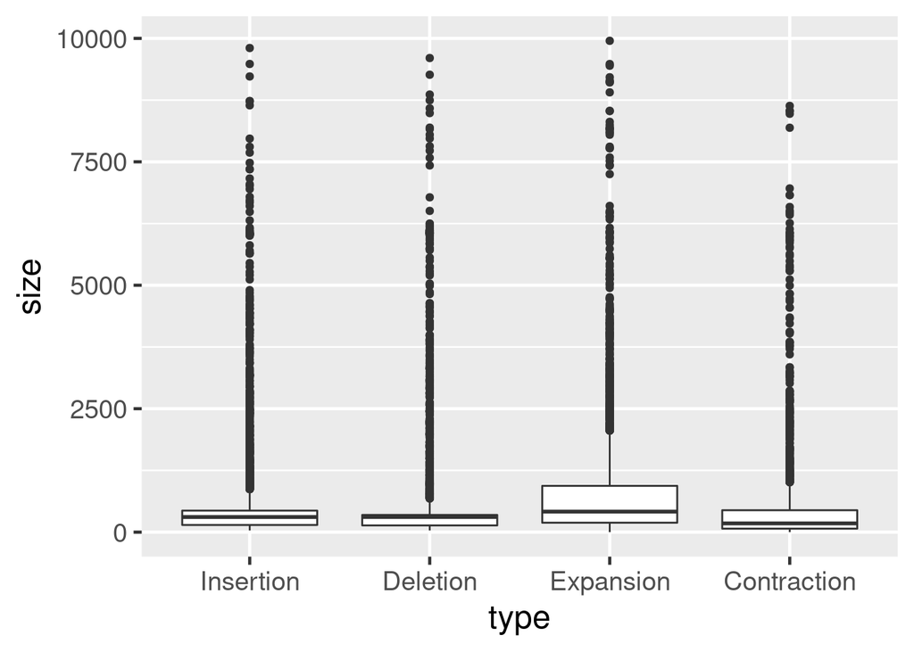

```r
ggplot(data, aes(x=type, y=size))+
  geom_boxplot()
```

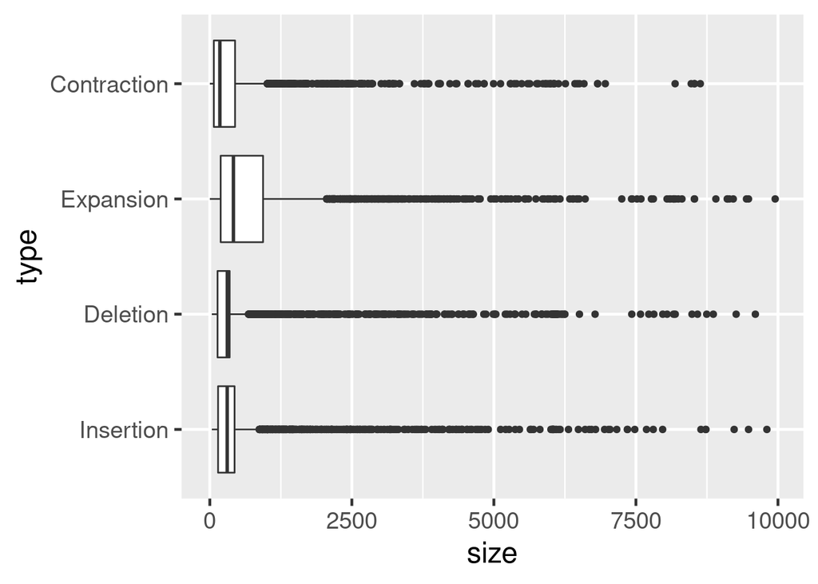

```r
ggplot(data, aes(x=type, y=size))+
  geom_boxplot()+
  coord_flip()
```

## Violin Plot

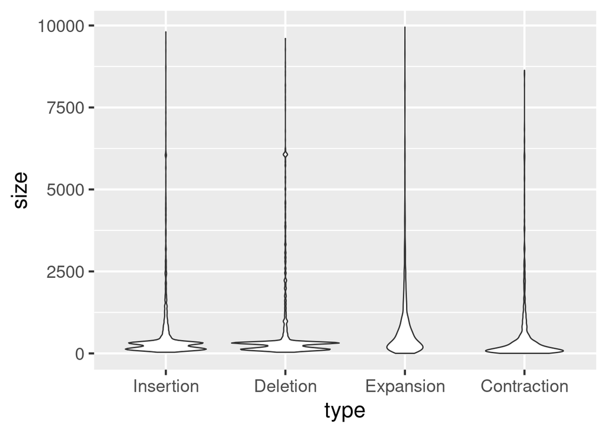

```r
ggplot(data, aes(x=type, y=size))+
  geom_violin()
```

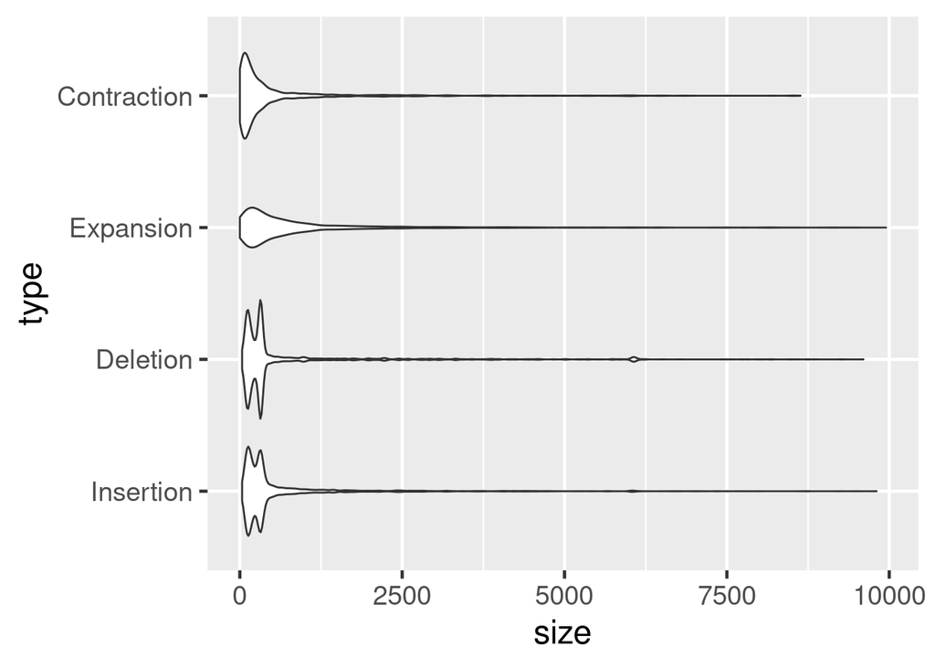

```r
ggplot(data, aes(x=type, y=size))+
  geom_violin()+
  coord_flip()
```

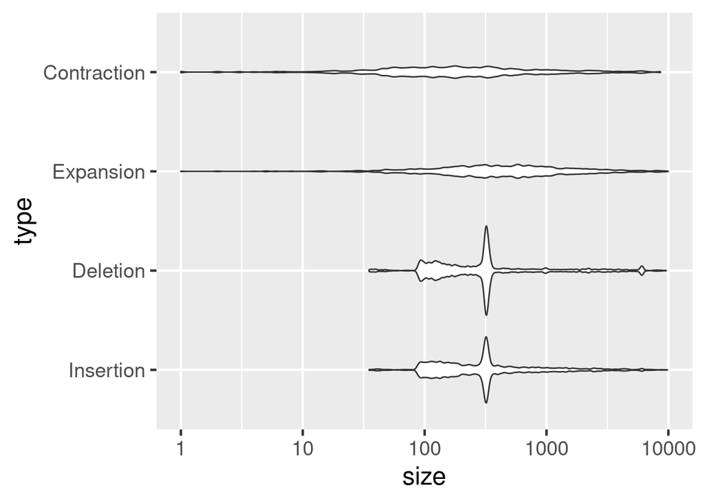

```r
ggplot(data, aes(x=type, y=size))+
  geom_violin(adjust=0.2)+
  scale_y_log10()+
  coord_flip()
```

## Desnsity Plot

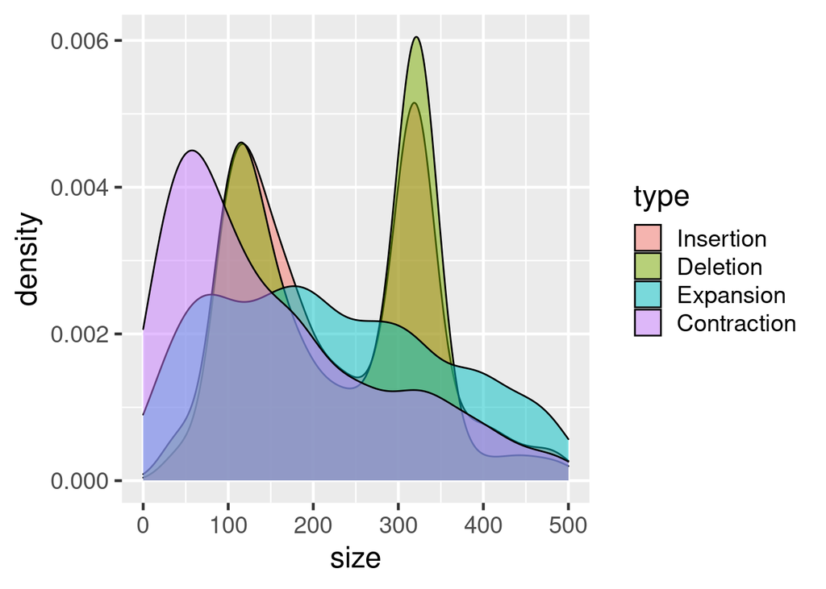

```r
ggplot(data, aes(x=size, fill=type))+
  geom_density(alpha=0.5)+
  xlim(0,500)
```

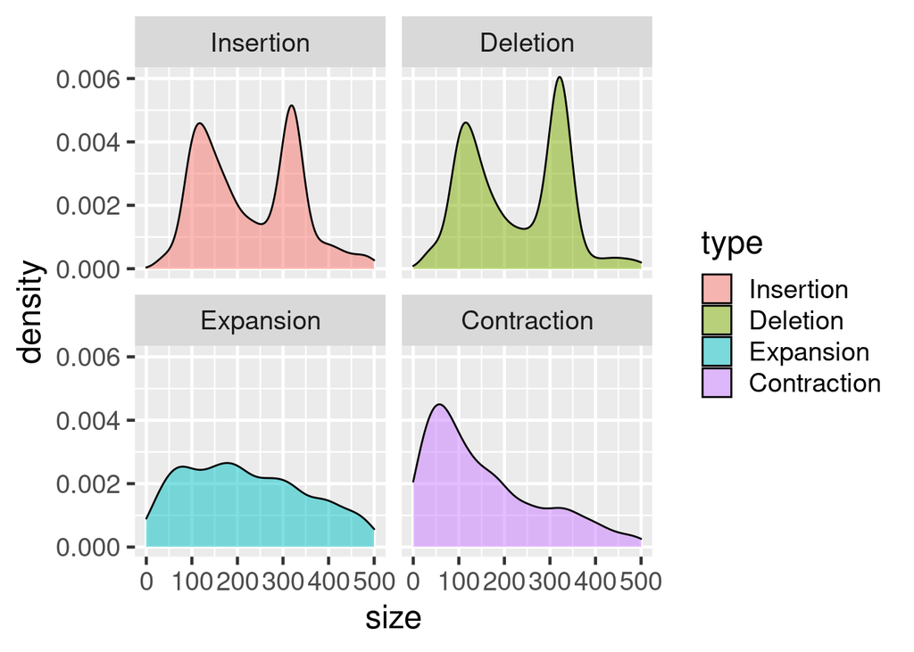

```r
ggplot(data, aes(x=size, fill=type))+
  geom_density(alpha=0.5)+
  xlim(0,500)+
  facet_wrap(~type)
```

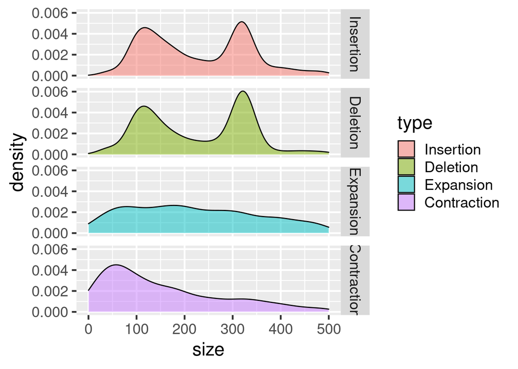

```r
ggplot(data, aes(x=size, fill=type))+
  geom_density(alpha=0.5)+
  xlim(0,500)+
  facet_grid(type ~ .)
```

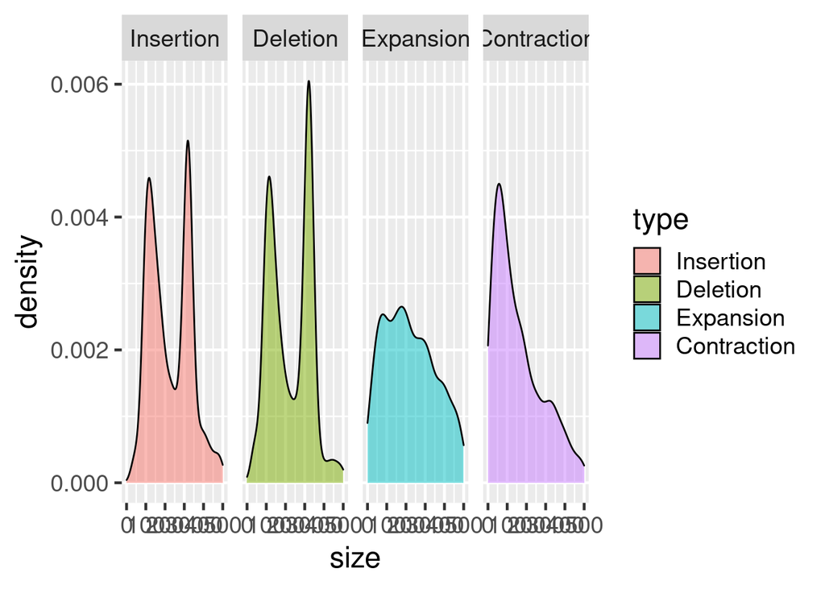

```r
ggplot(data, aes(x=size, fill=type))+
  geom_density(alpha=0.5)+
  xlim(0,500)+
  facet_grid(. ~type)
```

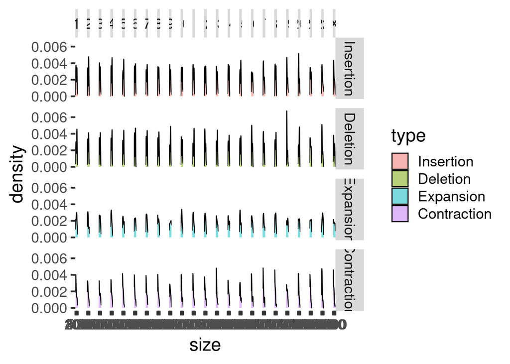

```r
ggplot(data, aes(x=size, fill=type))+
  geom_density(alpha=0.5)+
  xlim(0,500)+
  facet_grid(type ~chrom)
```

## Pie Chart

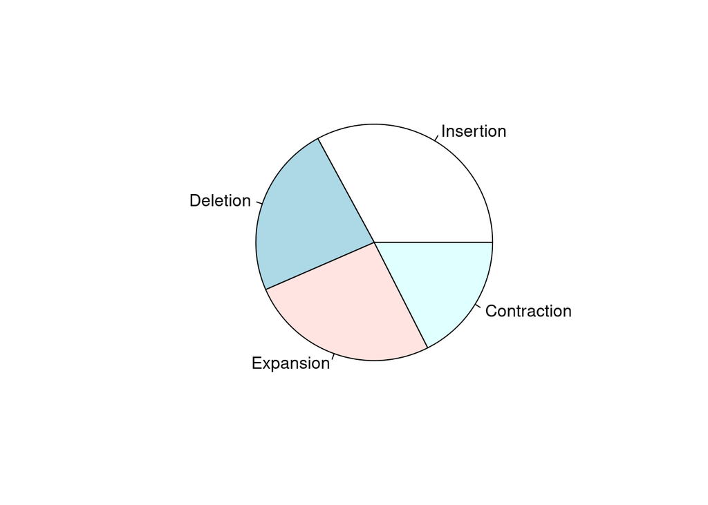

```r
type_counts <- summary(data$type)
pie(type_counts)
```

## Arrange Plot

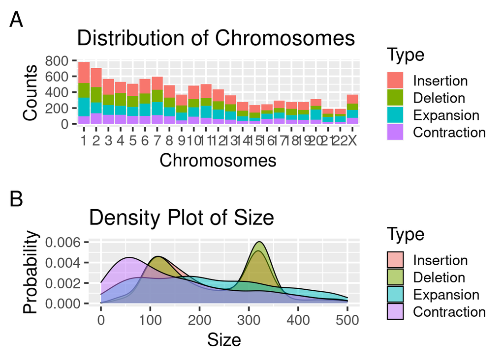

```r
f1 <- ggplot(data, aes(x=chrom,fill=type))+
  geom_bar()+
  labs(title = "Distribution of Chromosomes",
       x="Chromosomes", y="Counts",
       tag = "A")+
  guides(fill=guide_legend(title = "Type"))

f2 <- ggplot(data, aes(x=size, fill=type))+
  geom_density(alpha=0.5)+
  xlim(0,500)+
  labs(title = "Density Plot of Size",
       x = "Size",
       y = "Probability",
       tag = "B")+
  guides(fill=guide_legend(title = "Type"))


  grid.arrange(f1, f2, nrow=2, ncol=1)
```